# Project 3

Diana Rueda

12/4/2021

# Introduction

Time series can contain periodic trends which can be very complex. Spectral analysis allows us to distinguish the underlying periodic behavior in these time series. We no longer analyze it in terms of past values. Instead we use frequencies and periods.

An example of periodic behavior in a time series is shown in electroencephalograms which are tests that record electrical brain signals.

##### In this report you will find:

##### 1. Material and Methods

##### 2. Results

##### 3. Appendix

# 1. Material and Methods

The dataset EEG can be found under the library ‘TSA’. It contains the electrical brain activity of a patient suffering a seizure. It took 256 samples per second and has a length of 13000 observations. They were recorded for under a minute. In order to analyze this data we will make use of the visualization of the time series, calculation of the raw and smoothed periodogram and confidence intervals.

Figure 1 shows the complete time series. We can observe the precence of some periodicity. In order to observe its periodic behaviour more closely Figure 2 shows a closer look at a portion of the time series ranging along 500 observations.

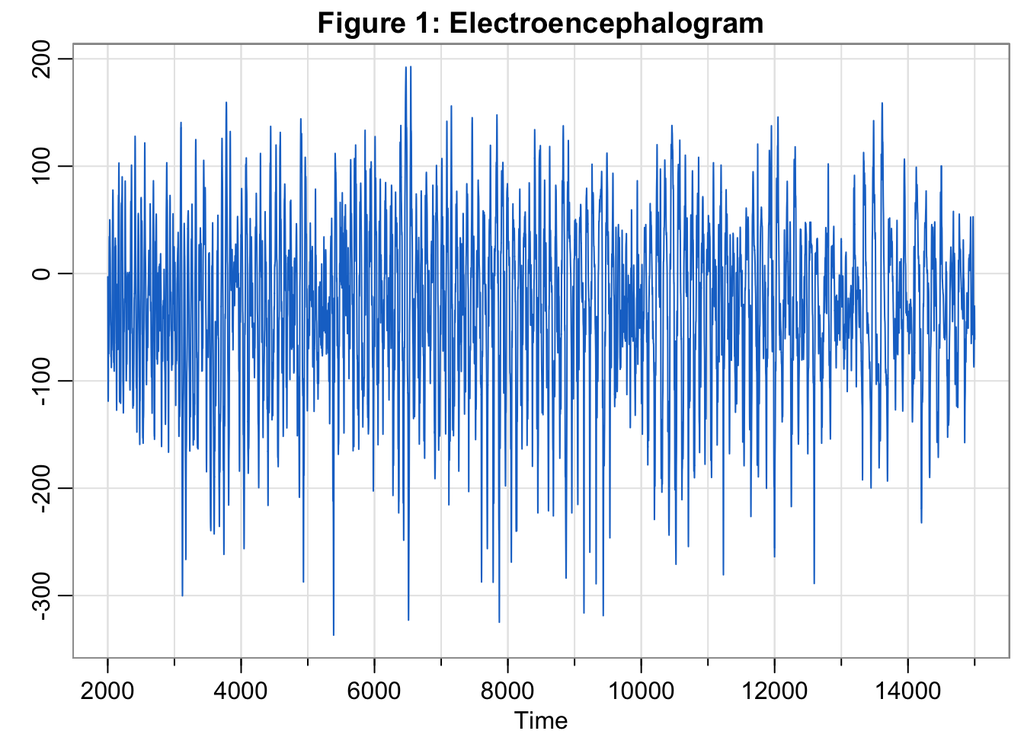

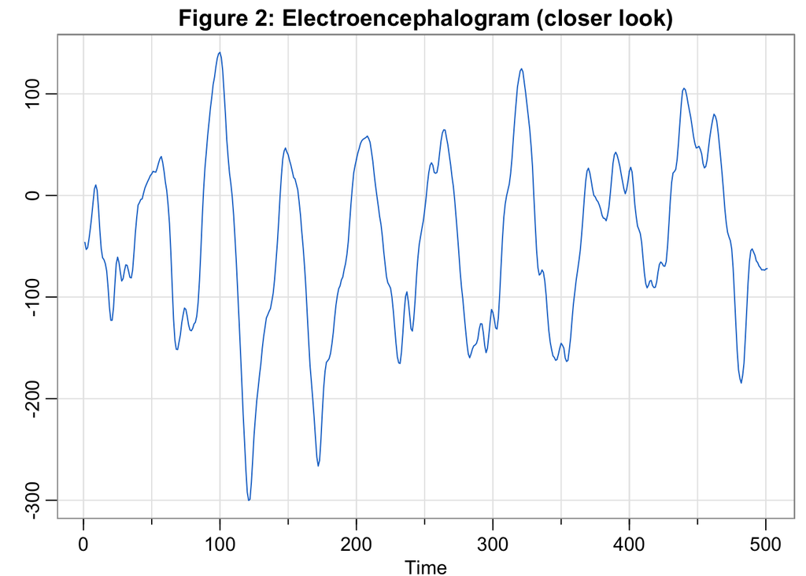

The periodogram is an estimate of the spectral density which helps us identfy the significant periodic components of our data. Through it we can find the dominant frequency of our time series. The raw periodogram shown in Figure 3 shows significant spikes at very small frequencies. If we calculate an interval from this periodogram it will be too wide to be useful. Thus we use a smoothed periodogram to see the averages over nearby frequencies. This helps filter non significant frequencies and the display is strightfoward.

### Figure 3:

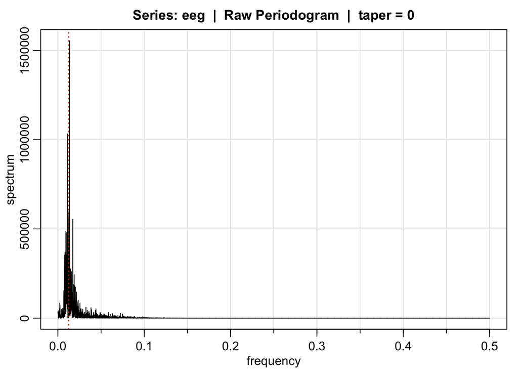

# 2. Results

### Figure 4:

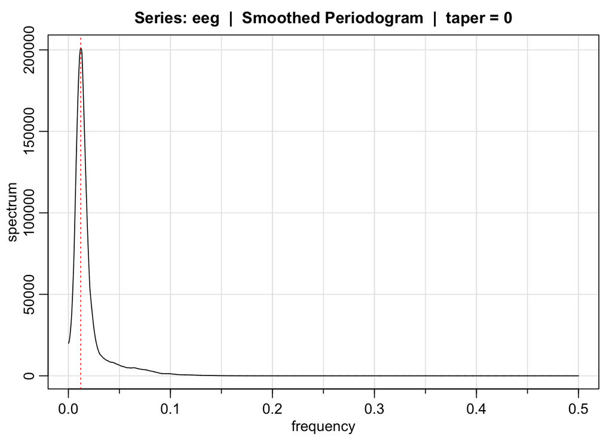

Figure 4 reveals that the frequency at the peak is 0.0121.

Consequently we found that the 95% confidence intercal for the underlyng spectral density at frequency 0.0121 is (172575.5 , 237395.4 ).

# 3. Appendix:

```r
# Figure 1
library(TSA)
library(astsa)
data(eeg)
tsplot(eeg, main = "Figure 1: Electroencephalogram", ylab = "",col = 4, margin = 0)

# Figure 2
tsplot(eeg[1000:1500], main = "Figure 2: Electroencephalogram (closer look)", ylab = "",col = 4, margin = 0)
# figure 3
eeg_pgram = mvspec(eeg, taper=0, log="no")
abline(v=1/80, lty= 'dotted', col = 'red')

# Figure 4
eeg_pgram_k = mvspec(eeg, taper=0, log="no", kernel("modified.daniell", c(51,51)) )
abline(v=53/4374, lty="dotted", col = 'red')
i = which(eeg_pgram_k$details[,3] == max(eeg_pgram_k$details[,3]))
freq = eeg_pgram_k$details[i,1]
#library(MASS)
#freq_f = fractions(freq)

df  = eeg_pgram_k$df
U   = qchisq(.025, df)
L   = qchisq(.975, df)
ci_l = df*eeg_pgram_k$spec[i]/L
ci_u = df*eeg_pgram_k$spec[i]/U
```